# Analysis

Chase Clark

January 23, 2019

The IDBac version used to create the SQL was: https://github.com/chasemc/IDBacApp/commit/9c7609ade28155e165c6e4319f12b55f6108b216

This can be installed via: devtools::install_github(“chasemc/IDBacApp@9c7609a”)

Means and standard deviations were computed by 1,000 random-sample bootstraps.

```
## [1] "IndividualSpectra" "XML"               "metaData"
## [4] "version"
```

# Boxplot Comparisons of Biological andf Technical Replicates

This section shows the effects of 1 to 3 technical replicates at each of 12 biological replicates.

Technical replicates were used to create a merged peak list at each biological replicate, then each bioligcal replicate merged. Peak-handling (eg binning settings) were kept the same for both technical and biological replicates. Percent peak presence was kept at 50% for both technical and biological replicates.

The boxplots below depict each of the four isolates against each other. As a reminder: - B004 and A046 share 100% 16S rRNA sequence - A046 and A019 share 98.03% 16S rRNA sequence (29 nt) - 172-6 is an *Enterococcus* sp. See the Study Design document for more details

## B004

### B004 vs A019

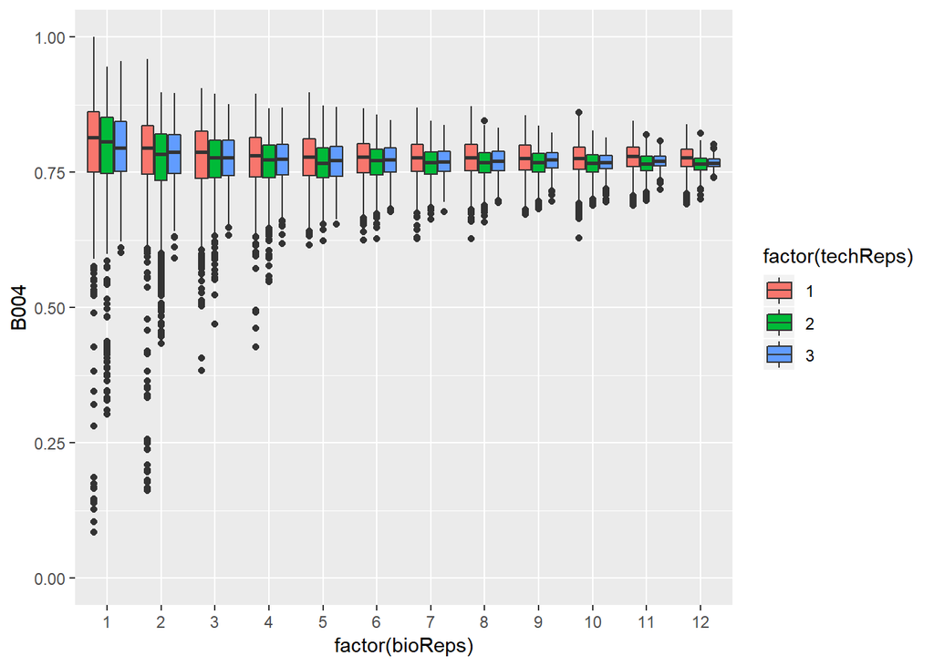

### B004 vs A046

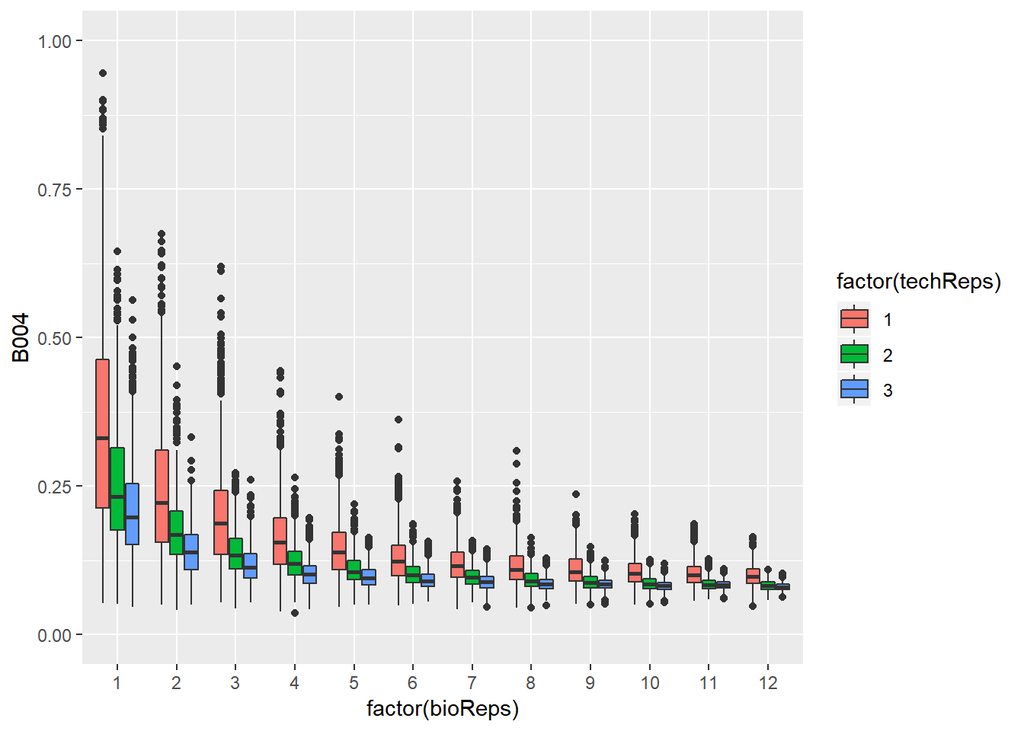

### B004 vs 172-6

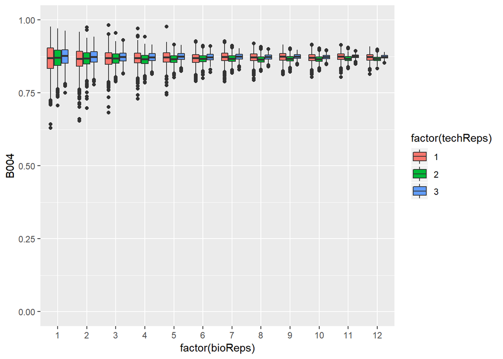

## A046

### A046 vs 172-6

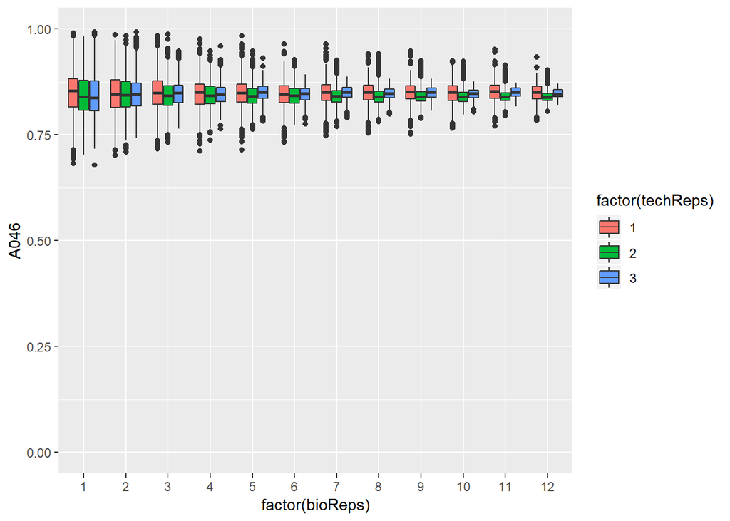

### A046 vs A019

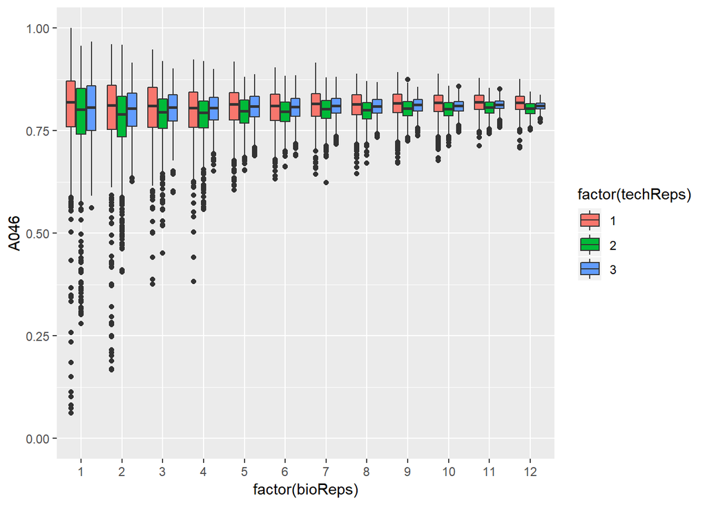

### A046 vs B004

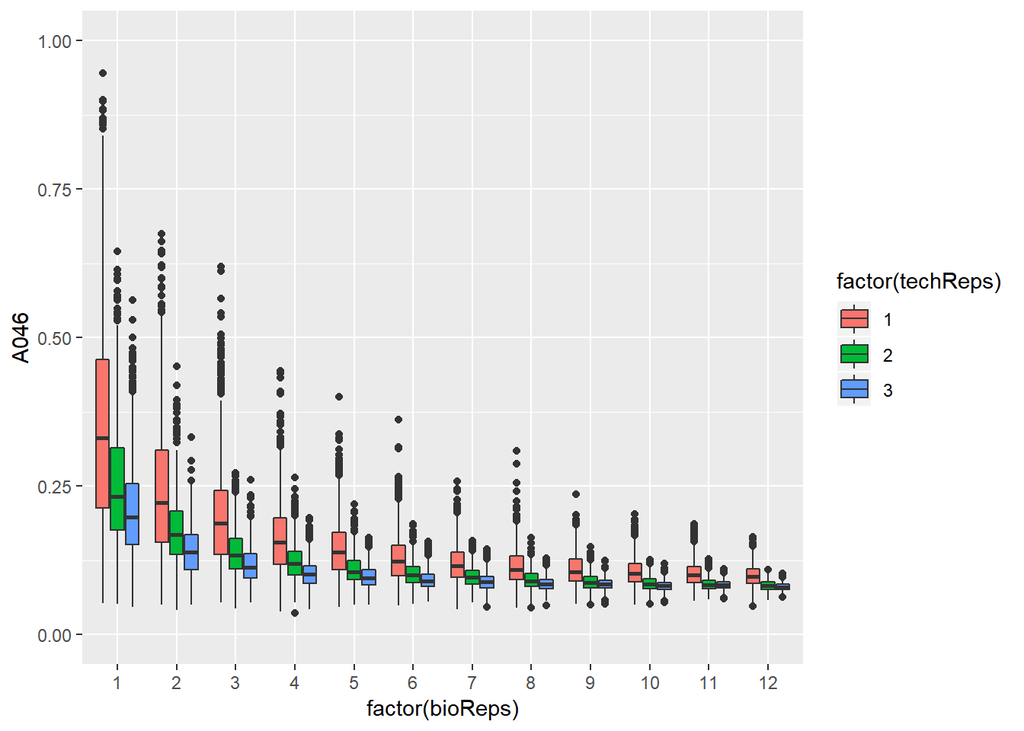

## A019

### A019 vs 172-6

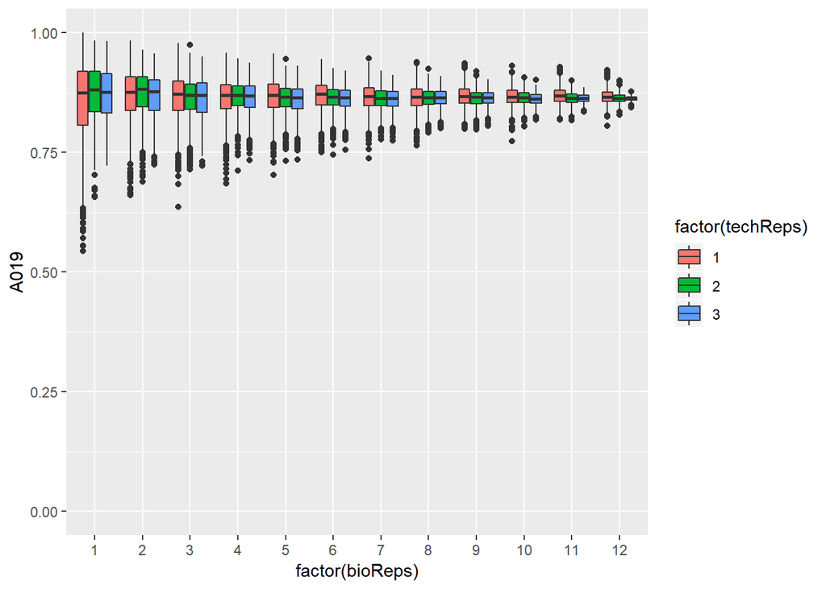

### A019 vs A046

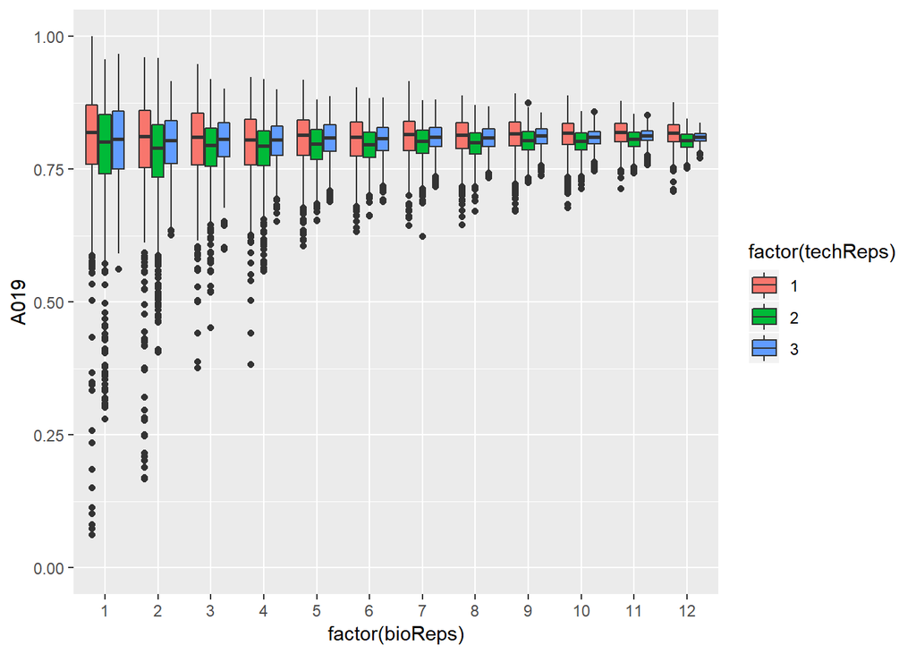

### A019 vs B004

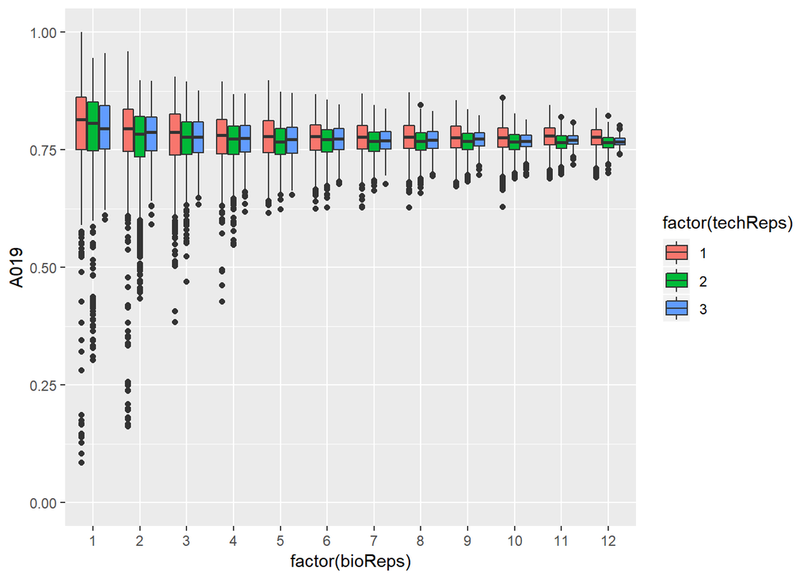

# Effect of Technical Replicates with increaing Biological Replicates (Standard Deviations)

This section of the document depicts the effect of adding between 1 and 3 technical Replicates in scenarios where 1 to 12 biological replicates are included. The measurements depicted are the standard deviation of cosine similarity.

*Note: It is important to remember here that at each biological replicate level, technical replicates are not additive but **multiply** the number of samples*

## Effects measured against A046

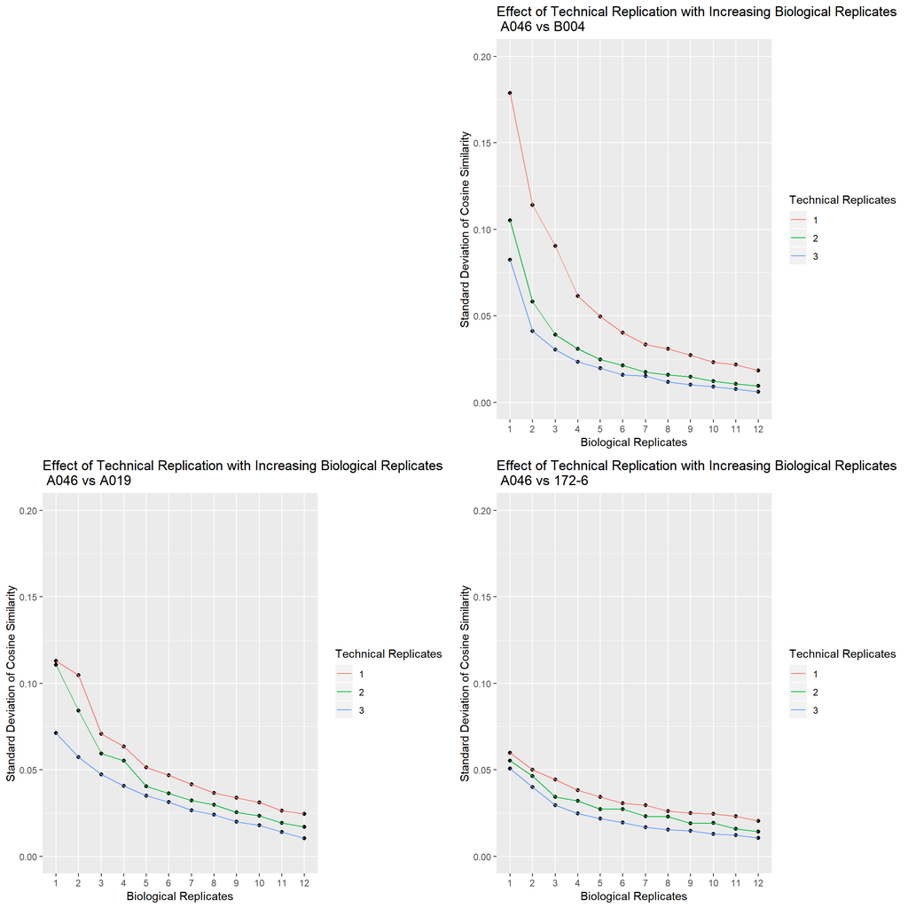

## Effects measured against B004

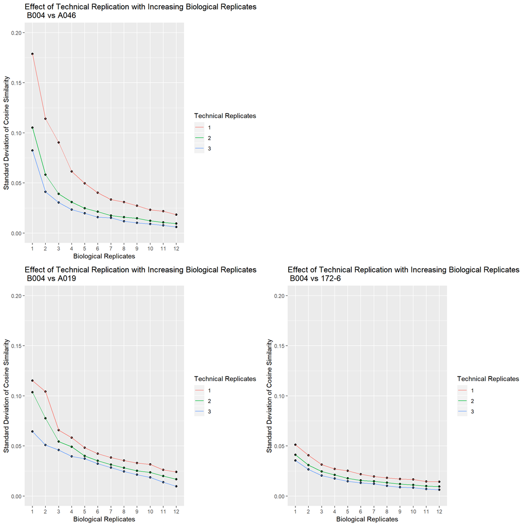

## Effects measured against A019

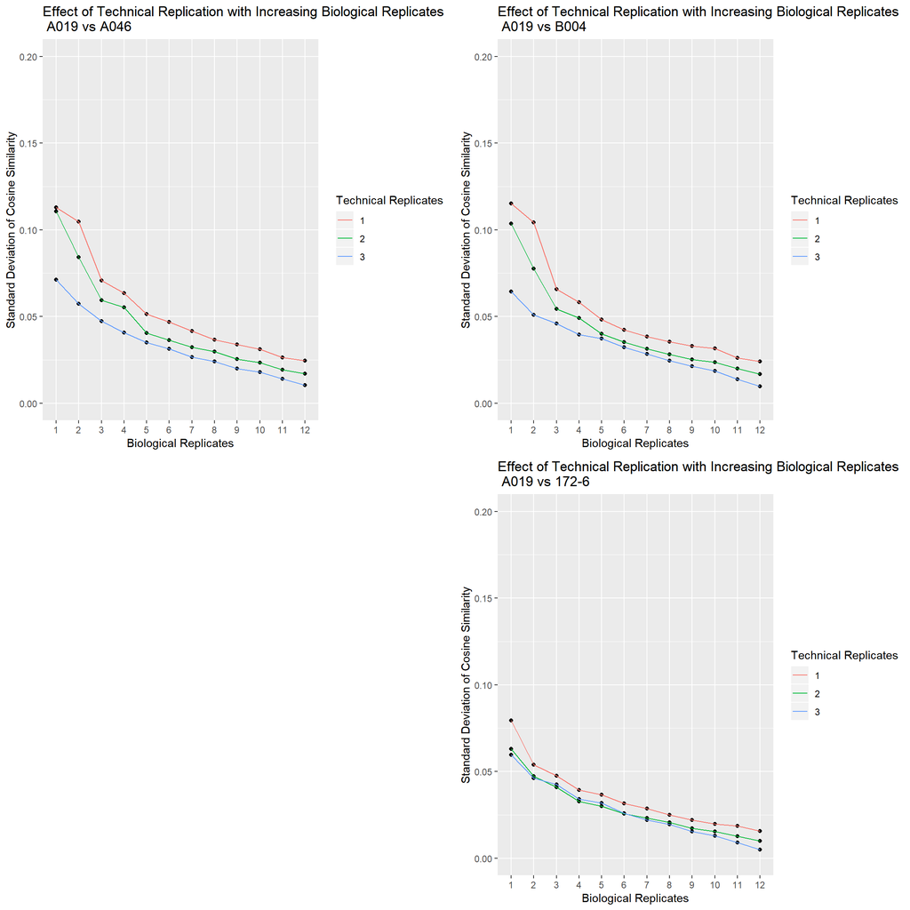

## Effects measured against 172-6

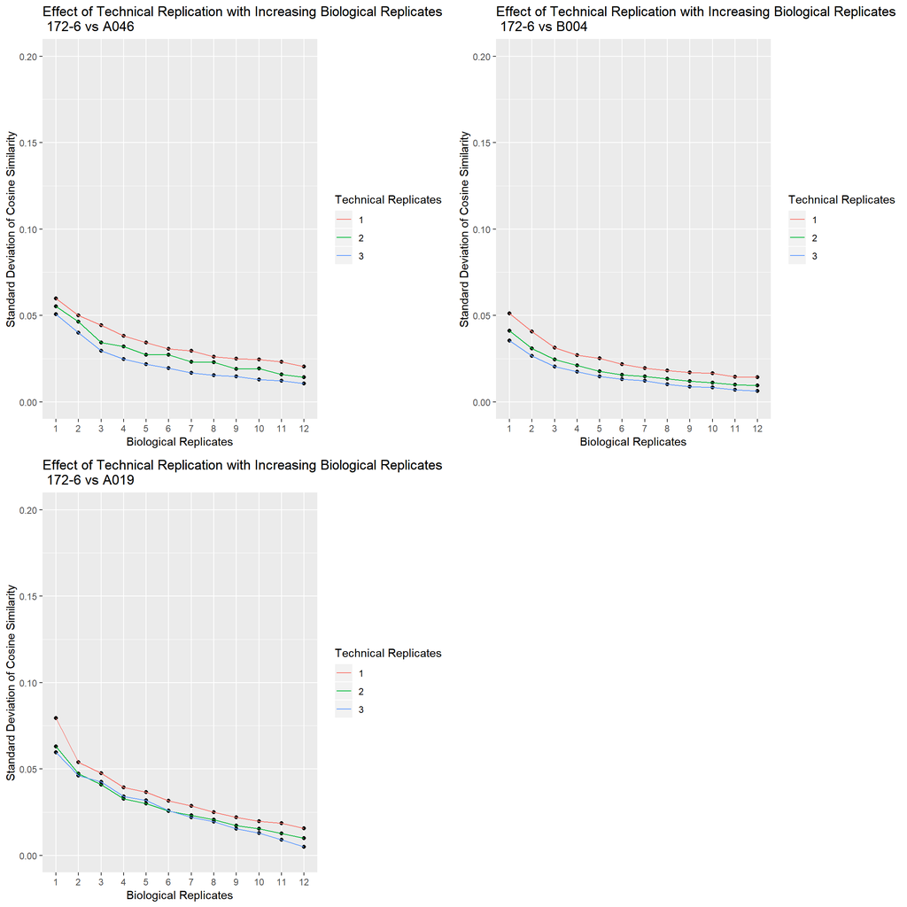

# Effect of Technical Replicates with increaing Biological Replicates (Means)

This section of the document depicts the effect of adding between 1 and 3 technical Replicates in scenarios where 1 to 12 biological replicates are included. The measurements depicted are the means of cosine similarity.

*Note: It is important to remember here that at each biological replicate level, technical replicates are not additive but **multiply** the number of samples*

## Effects measured against A046

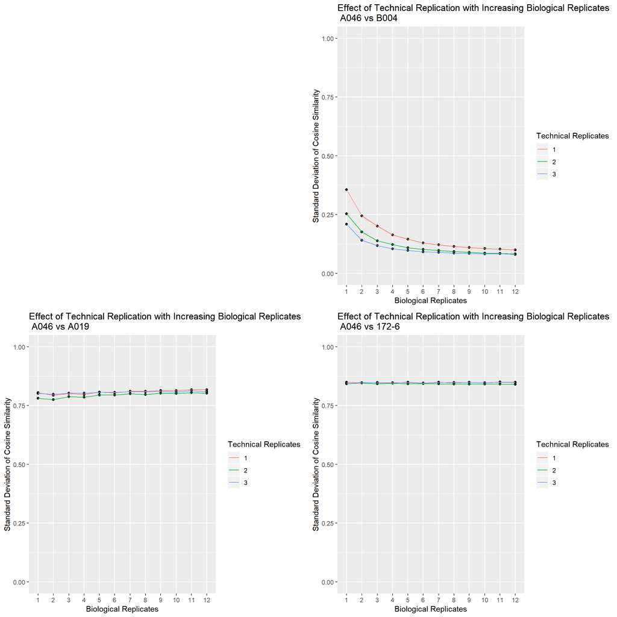

## Effects measured against B004

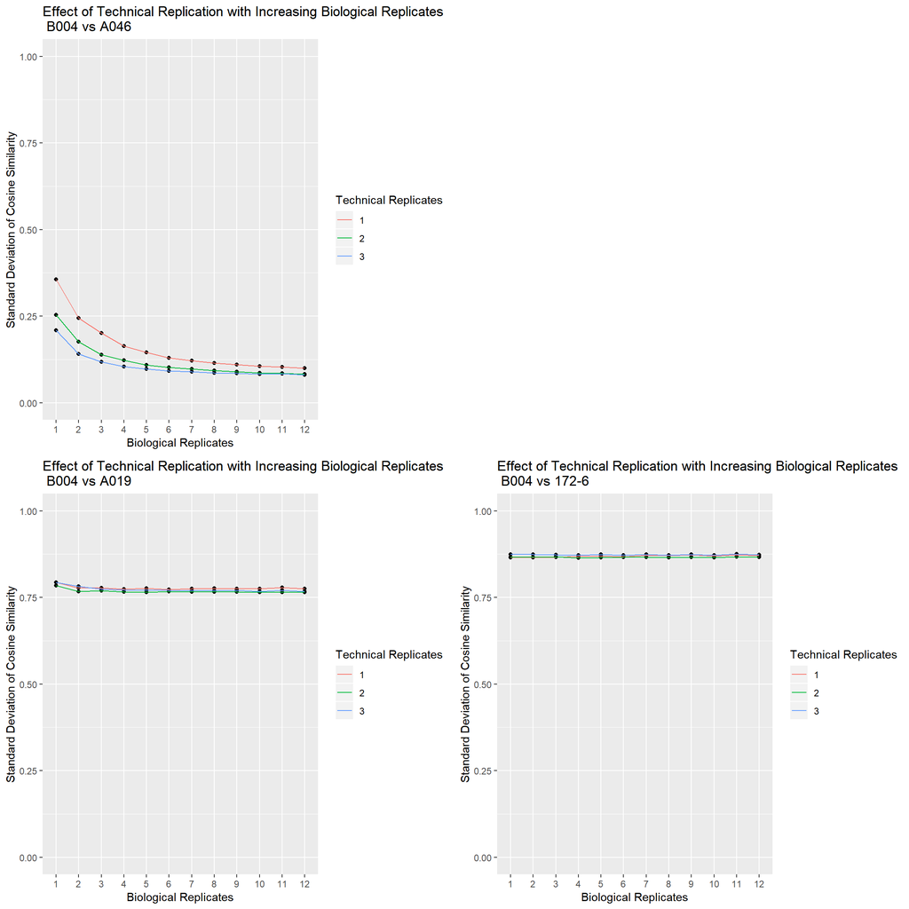

## Effects measured against A019

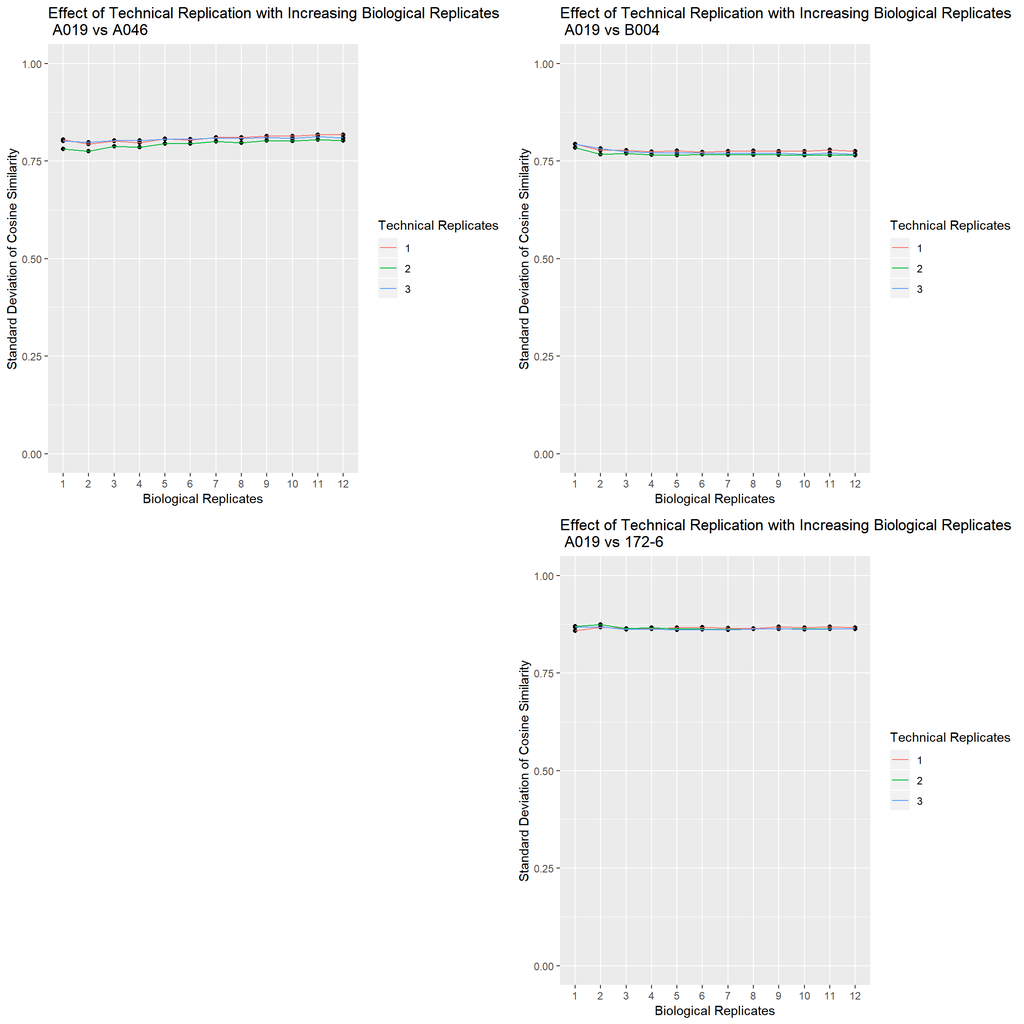

## Effects measured against 172-6

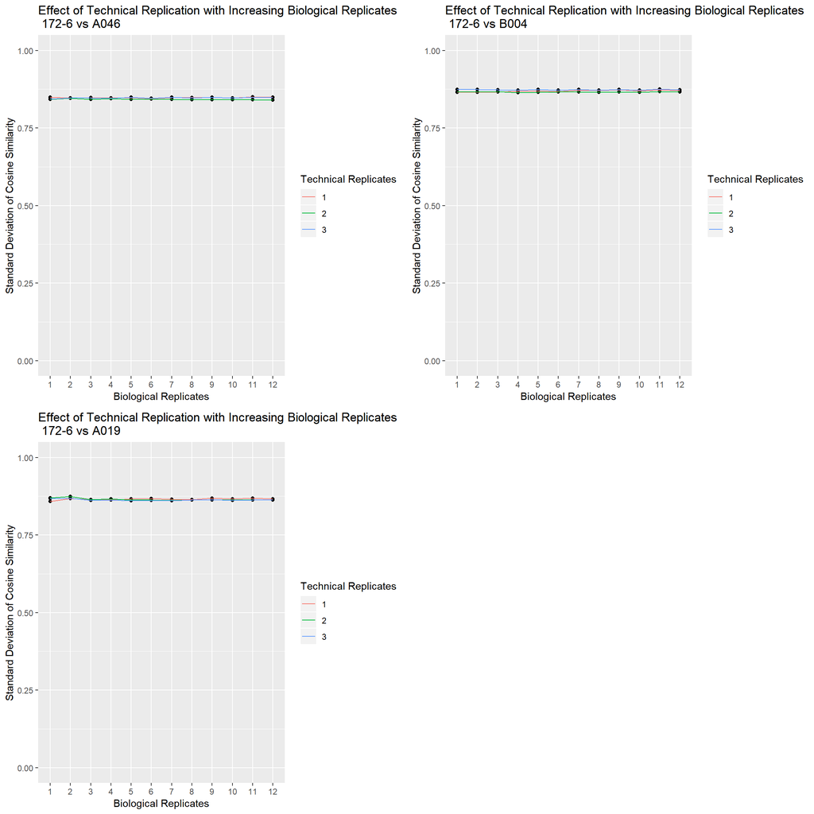

# Evaluating the effects of increasing MALDI sample spots

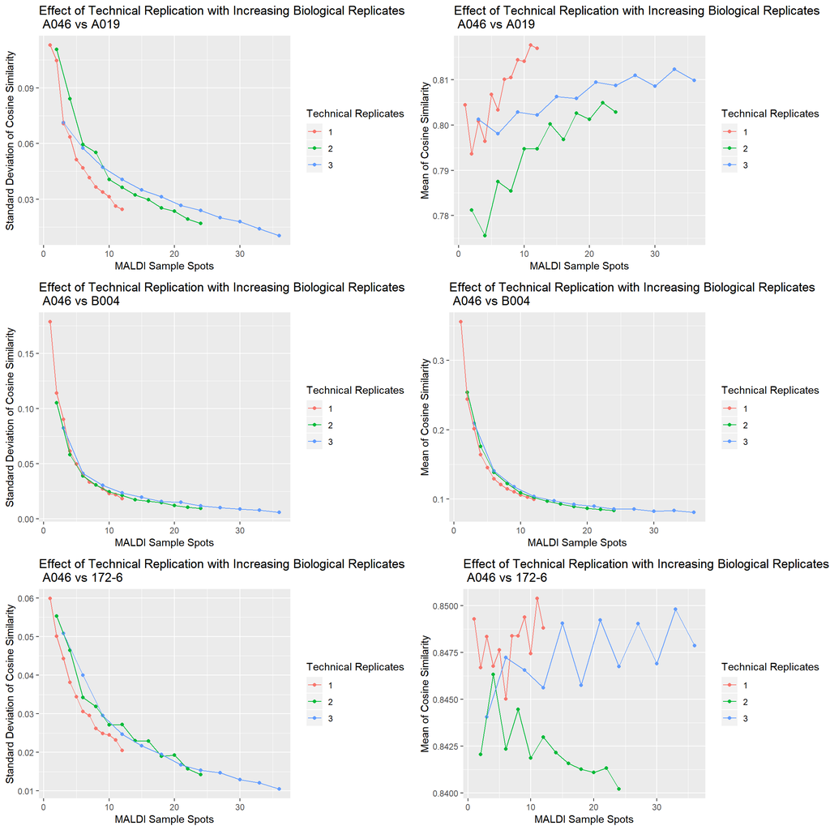

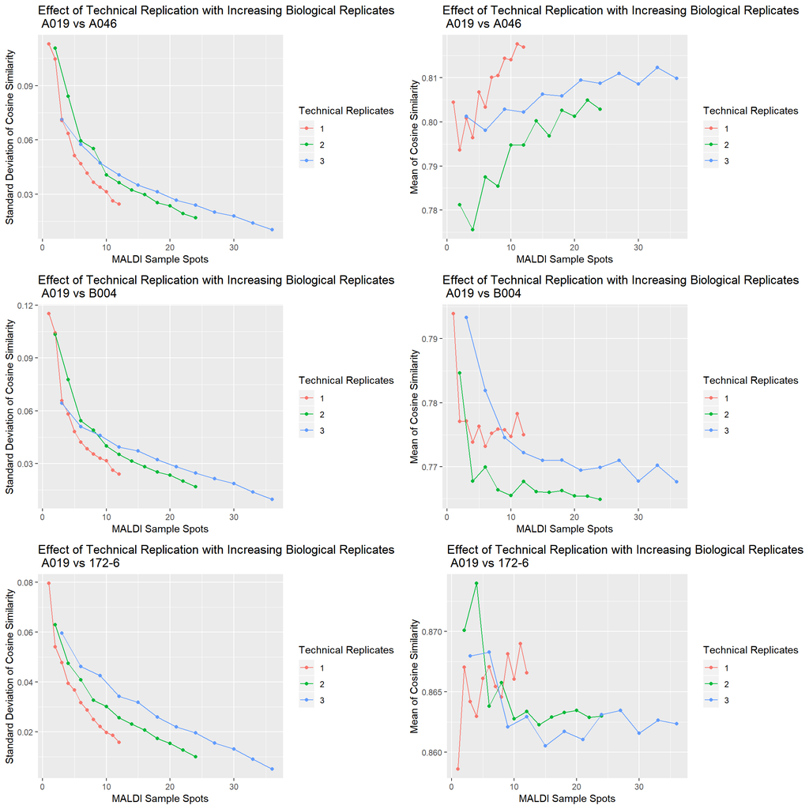

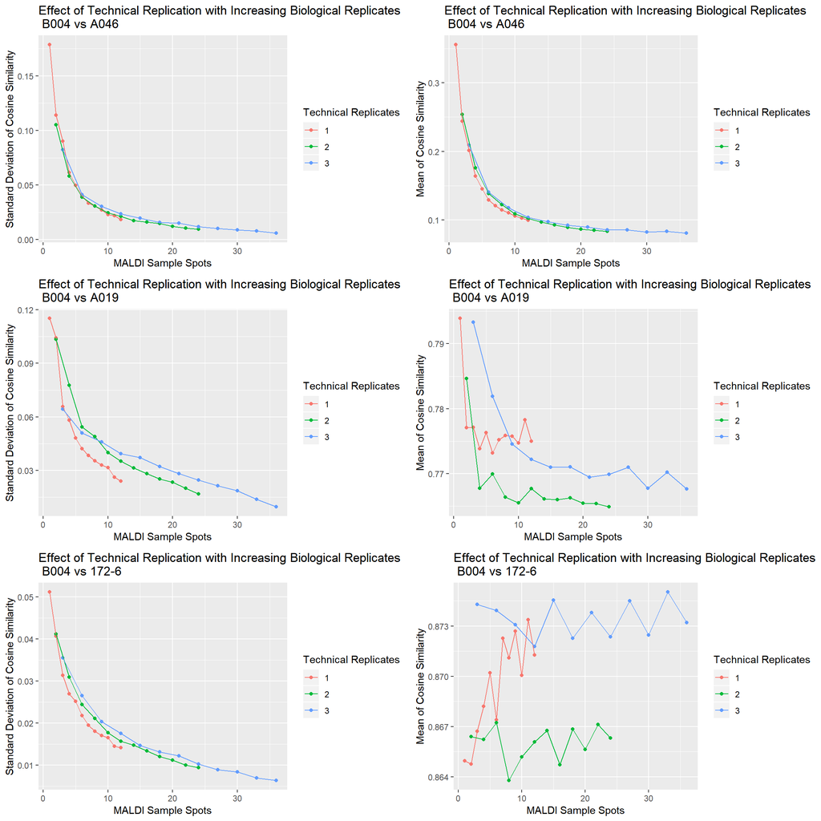

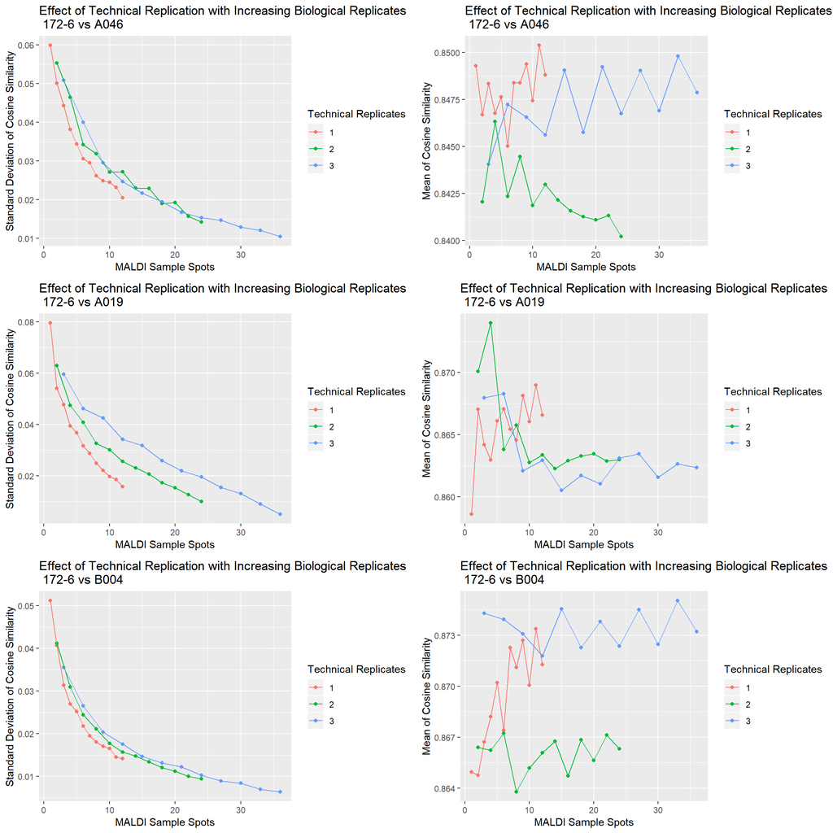